# Lecture ??

## Probability integral transform (PIT)

Definition:
$$pit_i = \text{Prob}(\hat{y}_i<y_i|\mathbf{y}_{-i})$$

- Linked to leave-one-out cross-validation
- $pit_i$ shows how well the ith data point is predicted by the rest of the data
- Very small values indicate “suprising” observation under the model
- For well-calibrated, the PIT values should be approximately uniformly distributed.

## Probability integral transform (PIT)

How to compute:

```r
# tell inlabru you want to compute DIC
bru_options_set(control.compute = list(cpo = TRUE))
fit = bru(cmp, lik)
# see the results
head(fit$cpo$pit)
```

```
[1] 0.2627104 0.9086035 0.1865239 0.5273202 0.8405274 0.9482781
```

## Good and Bad PIT plots

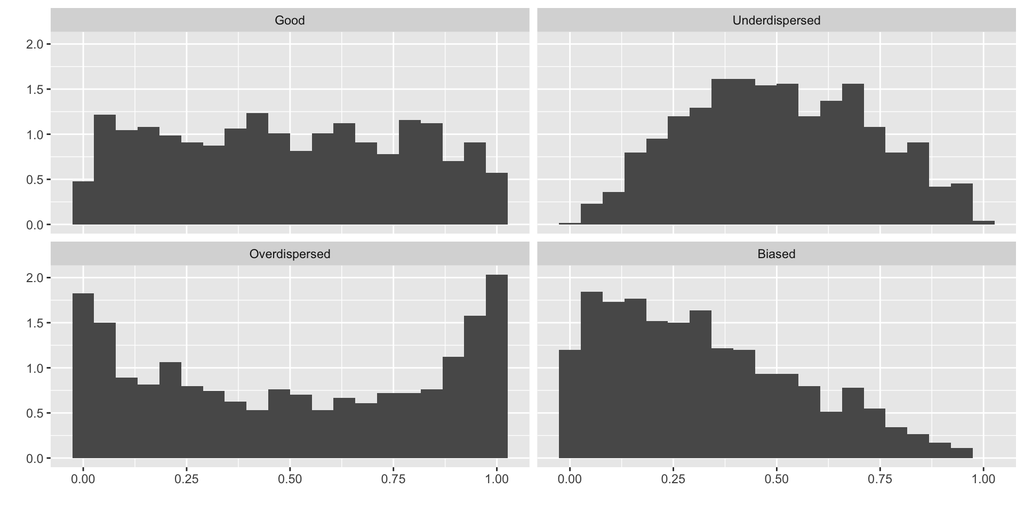

## Other scores

In the literature there are many proposed scores for evaluate predictions. For example:

- Dawid-Sebastian score
- Log-score
- Continuous rank probility score (CRPS)
- Brier score
- …

They all have their strength and wakness and which one is better depends on the goals of the model.

`inlabru` does not provide such scores automatcally, but they can be computed using simulations from the posterior distribution.

## Example: CRPS for Poisson data

Our model:
$$\begin{eqnarray}
y_i|\lambda_i & \sim \text{Poisson}(\lambda_i),&\ i = 1,\dots,N_{\text{data}}\\
\log(\lambda_i) = \eta_i &= \beta_0 + \beta_1 x_i
\end{eqnarray}$$

Simulate data and fit the model:

```r
df_pois <- data.frame(
  x = rnorm(50),
  y = rpois(length(x), exp(2 + 1 * x))
)
cmp = ~ Intercept(1) + cov(x, model = "linear")
lik = bru_obs(formula = y~.,
              family = "poisson",
              data = df_pois)
fit_pois <- bru(cmp, lik)
```

## Example: CRPS for Poisson data

The CRPS score is defined as:
$$\text{S}_{\text{CRPS}}(F_i, y_i) = \sum_{k=0}^\infty\left[\text{Prob}(Y_i\leq k|\mathbf{y})-I(y_i\leq k)\right]^2$$

Computational algorithm:

1. Simulate $\lambda^{(j)}\sim p(\lambda|\text{data}), j = 1,\dots, N_{\text{samples}}$ using `generate()` (size $N\times N_\text{samples}$).
2. For each $i=1,\dots,N_{\text{data}}$, estimate $r_{ik}=\text{Prob}(Y\leq k|\text{data})-I(y_i\leq k)$ as
   $$\hat{r}_{ik} = \frac{1}{N_\text{samples}} \sum_{j=1}^{N_\text{samples}}
   \{
   \text{Prob}(Y\leq k|\lambda^{(j)}_i)-I(y_i\leq k)
   \} .$$
3. Compute
   $$S_\text{CRPS}(F_i,y_i) = \sum_{k=0}^{K} \hat{r}_{ik}^2$$

## Example: CRPS for Poisson data

Implementation:

```r
# some large value, so that 1-F(K) is small
max_K <- ceiling(max(df_pois$y) + 4 * sqrt(max(df_pois$y)))
k <- seq(0, max_K)
kk <- rep(k, times = length(df_pois$y))
i <- seq_along(df_pois$y)
pred_pois <- generate(fit_pois, df_pois,
  formula = ~ {
    lambda <- exp(Intercept + x)
    ppois(kk, lambda = rep(lambda, each = length(k)))
  },
  n.samples = 2000
)
results <- data.frame(
  i = rep(i, each = length(k)),
  k = kk,
  Fpred = rowMeans(pred_pois),
  residuals =
    rowMeans(pred_pois) - (rep(df_pois$y, each = length(k)) <= kk)
)

crps_scores <-
  (results %>%
    group_by(i) %>%
    summarise(crps = sum(residuals^2), .groups = "drop") %>%
    pull(crps))
summary(crps_scores)
```

```
    Min.  1st Qu.   Median     Mean  3rd Qu.     Max.
  0.4535   2.7921   7.5235  14.3722  18.0851 112.6169
```